# Geostats II

Maggy Critchlow

5/27/2020

## Data Overview

This is the same data set from the last module, which contains precipitation data for 432 locations in California. Another way to predict precipitation over the entire state is to use kriging, which interpolates precipitation using the existing data points. Unlike IDW, however, this method shows variance, interpreted as error, which is useful in determining the effectiveness of the model. As discussed last time, this data is pretty skewed. Because normality is not essential in evaluating the data using kriging, I will not transform it to make it easier to interpret the output values (interpreting the log of a mm isn’t easy).

```r
bndCA <- readRDS("bndCA.rds")
gridCA <- readRDS("gridCA.rds")
precipCA <- readRDS("prcpCA.rds")
summary(precipCA$ANNUAL)
```

```
##    Min. 1st Qu.  Median    Mean 3rd Qu.    Max.
##    37.2   312.3   485.4   613.2   855.6  2337.0
```

### Packages Required

```r
library(sp)
library(sf)
library(ggplot2)
library(gstat)
```

### Map of California Precipitation Data

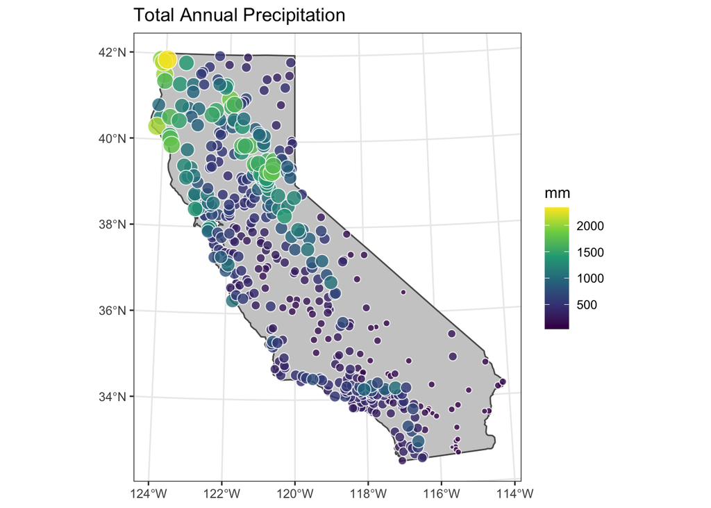

```r
plot1 <- ggplot() + geom_sf(data = bndCA, fill = "grey80") + geom_sf(data = precipCA, aes(fill = ANNUAL, size = ANNUAL), color = "white", shape=21, alpha=0.8) + scale_fill_continuous(type = "viridis", name = "mm") + guides(fill = guide_colorbar(), size="none") + labs(title="Total Annual Precipitation") + theme_bw()
plot1
```

As mentioned in the last module, the highest amounts of precipitation is in the northwest, which decreases moving towards the southeast. It will be interesting to see if the kriging model performs any better with the limited data in the eastern half of the state.

## Precipitation Prediction Using Kriging

### Variogram of Precipitation

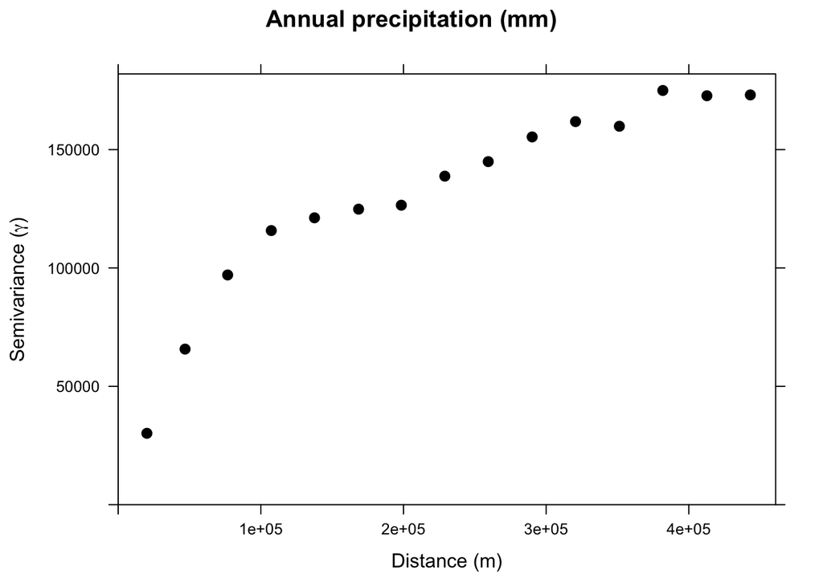

```r
precipCA.sp <- as_Spatial(precipCA)
precip.var <- variogram(ANNUAL~1, precipCA.sp)
plot(precip.var, pch=20, cex = 1.5, col = "black", ylab = expression("Semivariance ("*gamma*")"), xlab = "Distance (m)", main = "Annual precipitation (mm)")
```

### Model Fits

Between the two of these, the experimental model definitely seems to follow the pattern of the empirical data much more closely. This makes it a better choice for the prediction via kriging method.

#### Spherical Model

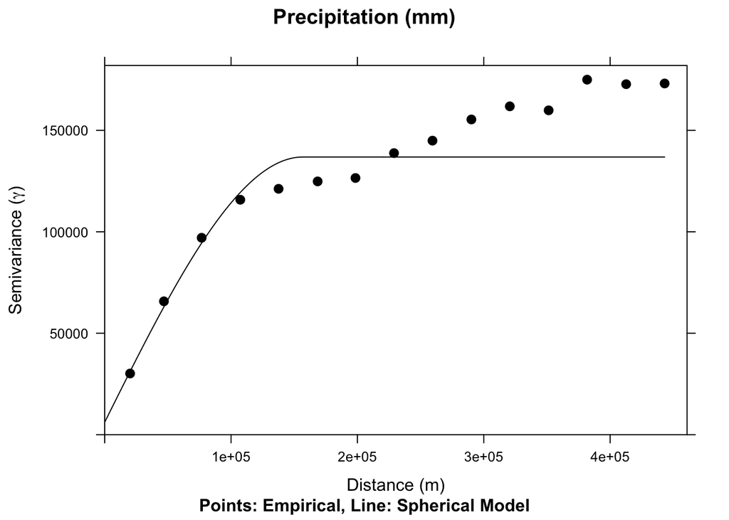

```r
sph.model <- vgm(psill = 150000, model = "Sph", range = 280000, nugget = 0)
sph.fit <- fit.variogram(object = precip.var, model = sph.model)
plot(precip.var, model = sph.fit, pch=20, cex=1.5, col="black", ylab=expression("Semivariance ("*gamma*")"), xlab="Distance (m)", main = "Precipitation (mm)", sub="Points: Empirical, Line: Spherical Model")
```

#### Experimental Model

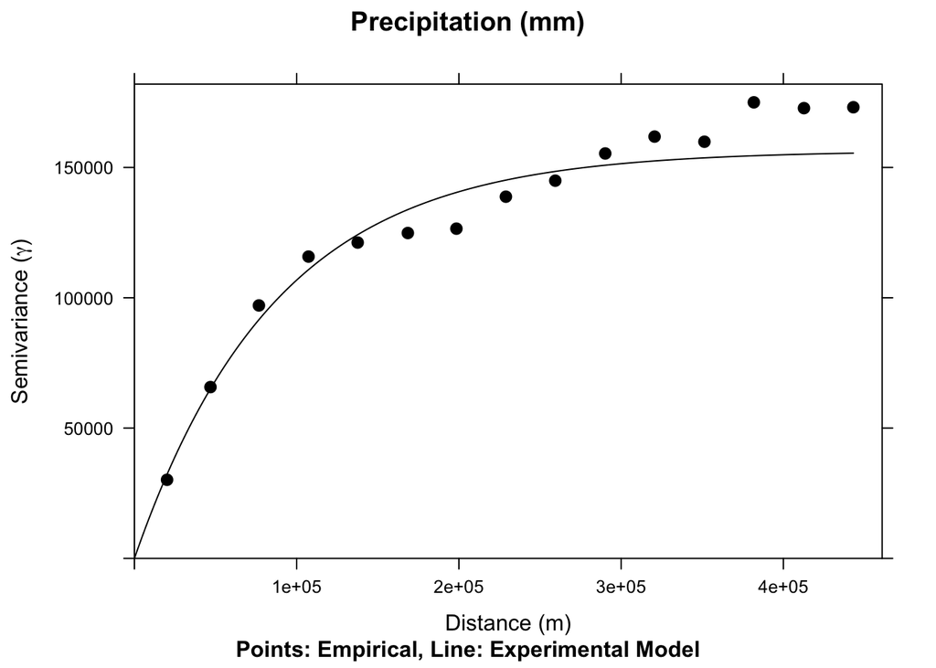

```r
exp.model <- vgm(psill = 150000, model = "Exp", range = 280000, nugget = 0)
exp.fit <- fit.variogram(object = precip.var, model = exp.model)
plot(precip.var, model = exp.fit,pch=20,cex=1.5,col="black", ylab=expression("Semivariance ("*gamma*")"), xlab="Distance (m)", main = "Precipitation (mm)", sub="Points: Empirical, Line: Experimental Model")
```

```r
precip.krige <- krige(ANNUAL~1, precipCA.sp, gridCA, model = exp.fit)
```

```
## [using ordinary kriging]
```

### Map of Precipitation Predictions and Variance

#### Precipitation Predictions by Kriging

```r
precip.krige.df <- as.data.frame(precip.krige)
head(precip.krige.df)
```

```
##           x        y var1.pred var1.var
## 1 -346692.4 445479.1  1869.182 33672.21
## 2 -336692.4 445479.1  2002.171 31798.23
## 3 -326692.4 445479.1  2050.669 34570.16
## 4 -316692.4 445479.1  1954.923 44847.37
## 5 -306692.4 445479.1  1801.063 53202.57
## 6 -296692.4 445479.1  1635.616 55173.53
```

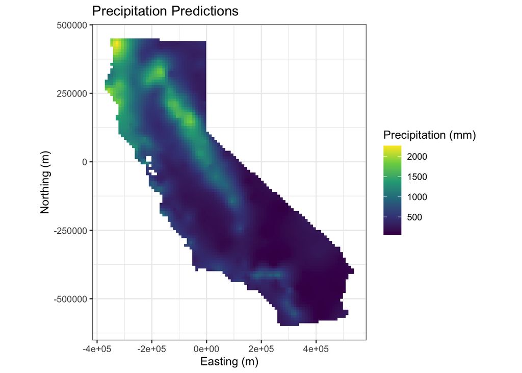

```r
plot2 <- ggplot() + geom_raster(data = precip.krige.df, aes(x = x, y = y, fill = var1.pred)) + scale_fill_continuous(type = "viridis", name = "Precipitation (mm)") + labs(x = "Easting (m)", y = "Northing (m)", title = "Precipitation Predictions") + coord_fixed() + theme_bw()
plot2
```

This looks like a pretty good prediction, based on the values from the precipitation data. Overall, it looks like the patterns stay mostly the same, and looks how we would expect it to. However, it’s important to check the variance, which represents the error in this method, before deciding if this is a good model or not.

#### Precipitation Variance by Kriging

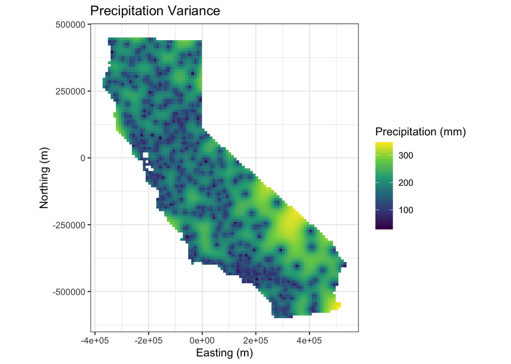

```r
plot3 <- ggplot() + geom_raster(data = precip.krige.df, aes(x = x, y = y, fill = sqrt(var1.var))) + scale_fill_continuous(type = "viridis", name = "Precipitation (mm)") + labs(x= "Easting (m)", y = "Northing (m)", title = "Precipitation Variance") + coord_fixed() + theme_bw()
plot3
```

The variance of this model indicates that it’s a good fit as well. The highest amounts of variance are in the southeast, where the data are most spread out. Like IDW and probably most interpolation techniques, it seems to be most reliable with a large number of data points to draw from. It also looks like some of the spots with slightly higher variance may occur in areas with many points that have a wider range of values, such as in the northwest corner. If there is another underlying variable driving this pattern, the model could be picking up some of that unexplained variance. Cross-validation will test this model to ensure that it is generalizeable, and provide an R<sup>2</sup> statistic for interpretation.

## Cross Validation of Model

```r
precip.krige.cross <- krige.cv(formula = ANNUAL~1, locations = precipCA.sp, model = exp.fit, verbose = FALSE)
head(precip.krige.cross)
```

```
##             coordinates var1.pred  var1.var observed    residual      zscore
## 1 (280058.5, -167265.7) 279.07498 129055.64     52.1 -226.974982 -0.63181438
## 2 (355394.7, -480020.1)  78.26084  23128.45     52.2  -26.060836 -0.17136224
## 3   (416370.6, -551681)  62.38191  16104.63     67.2    4.818091  0.03796642
## 4 (415173.2, -566152.8)  53.40347  15554.60     60.1    6.696534  0.05369338
## 5 (418431.9, -516087.4)  87.79406  60513.22     78.0   -9.794058 -0.03981416
## 6 (405858.5, -567692.2)  97.50646  26134.25     37.2  -60.306461 -0.37304294
##   fold
## 1    1
## 2    2
## 3    3
## 4    4
## 5    5
## 6    6
```

```r
cor(precip.krige.cross@data$observed,precip.krige.cross@data$var1.pred)^2
```

```
## [1] 0.9020047
```

The cross-validation, which is leave-one-out validation method, indicates that the R<sup>2</sup> from the observed versus predicted values is 0.902. This model accurately predicts the precipitation values with a high degree of accuracy, and supports that this would be a useful model for interpreting these missing data points.

## Discussion

Kriging provides a more directed approach than IDW. Rather than guessing and checking weights for the dataset, using the variogram to fit a model provides more justification for the numbers chosen, and a better chance of finding the best fitting model. The variance provides some insight to the strongest and weakest areas of the model. However, kriging still seems to struggle in predictions for areas without a lot of data.